# Bellabeat Case Study

Patick Benesch

13 12 2021

This Case Study for the Google Data Analyst Certificate will perform data analyis for the company Bellabeat, in the smart device industry.

The dataset being used contains anonymous fitness tracker data that is public domain.

(dataset made available through Mobius, https://zenodo.org/record/53894#.X9oeh3Uzaao")

In the this case study I apply the findings to the “Bellatbeat App”, that according to the descrition, tracks health data such as activity and sleep, among others.

The following Questions will be answered:

1. What are some trends in smart device usage?
2. How could these Trends apply to Bellabeat customers?
3. How could these trends help influence Bellabeat marketing Strategy

I also include a data cleaning report.

### Stakeholders

The key stakeholders are the company’s founders Urška Sršen and Sando Mur. Another stakeholder is the marketing team.

### Executive summary

- The data contains tracker data from 33 users with 940 observations overall
- The data was collected within one month, from 2016-04-12 to 2016-05-12
- From the data it is not clear whether the user was a man or a woman
- People mostly log light activity such as walking, a minority uses the tracker to track higher intensity activities such as jogging
- On average users did over 7600 Steps per day
- Users did use the tracker to monitor calories burned and higher step counts correspond with a higher amount of calories burned
- Users of the trackers have a below average Body-Mass-Index (BMI) when compared to the average BMI in the USA
- Around 70 % of the users in the dataset did use the tracker to track their sleep
- It could be further investigated for what activities people use the tracker or how the tracker accounts for certain activities, as the data shows that some users on some days tracked calories burned while not tracking any steps, this could indicate other activities such as gymnastics

### Recommendations

The bellabeat app targets health conscious women who would use the app to track their activities, stress levels and sleep among others. Therefore the data analysis of the fitness tracker is relevant to the case.

From the data it appears that people use their smart devices to track their activities and count calories and some also use it to track their sleep. Since most activities logged are low intensity activities, it looks like the users of the tracker are not professional athletes but people who use it daily for wellbeing and to stay fit.

It would therefore imply that Bellabeat should target people who want to stay fit and healthy in their everyday lives and use the Bellabeat app to monitor their progress.

Bellatbeat should also highlight the benefits of using a fitness app to keep a healthy weight, as the data shows that fitness tracker users have a below average BMI.

Also, since on many days the tracker data shows no activity at all, a function that would remind users of using the tracker more often would be useful in the app. The data also shows that most of the users in the dataset do use the device to track their sleep, thus Bellabeat should also highlight that functionality.

The next section of this report will show the analysis in detail, starting with loading of needed libraries in R.

The next section of this report will show the analysis in detail, starting with loading of needed libraries in R.

### Loading relevant libraries

### Loading the Data

Specifically for this study I used four tables:

- dailyActivity_merged.csv
- sleepDay_merged.csv
- weightLogInfo_merged.csv
- hourlyIntensities_merged.csv

The data tables contains data of fitness tracker users.

#### Main table - daily activities

```
## 'data.frame':    940 obs. of  15 variables:
##  $ Id                      : num  1.5e+09 1.5e+09 1.5e+09 1.5e+09 1.5e+09 ...
##  $ ActivityDate            : chr  "4/12/2016" "4/13/2016" "4/14/2016" "4/15/2016" ...
##  $ TotalSteps              : int  13162 10735 10460 9762 12669 9705 13019 15506 10544 9819 ...
##  $ TotalDistance           : num  8.5 6.97 6.74 6.28 8.16 ...
##  $ TrackerDistance         : num  8.5 6.97 6.74 6.28 8.16 ...
##  $ LoggedActivitiesDistance: num  0 0 0 0 0 0 0 0 0 0 ...
##  $ VeryActiveDistance      : num  1.88 1.57 2.44 2.14 2.71 ...
##  $ ModeratelyActiveDistance: num  0.55 0.69 0.4 1.26 0.41 ...
##  $ LightActiveDistance     : num  6.06 4.71 3.91 2.83 5.04 ...
##  $ SedentaryActiveDistance : num  0 0 0 0 0 0 0 0 0 0 ...
##  $ VeryActiveMinutes       : int  25 21 30 29 36 38 42 50 28 19 ...
##  $ FairlyActiveMinutes     : int  13 19 11 34 10 20 16 31 12 8 ...
##  $ LightlyActiveMinutes    : int  328 217 181 209 221 164 233 264 205 211 ...
##  $ SedentaryMinutes        : int  728 776 1218 726 773 539 1149 775 818 838 ...
##  $ Calories                : int  1985 1797 1776 1745 1863 1728 1921 2035 1786 1775 ...
```

#### Sleep data

```
## 'data.frame':    413 obs. of  5 variables:
##  $ Id                : num  1.5e+09 1.5e+09 1.5e+09 1.5e+09 1.5e+09 ...
##  $ SleepDay          : chr  "04.12.2016 00:00" "4/13/2016 12:00:00 AM" "4/15/2016 12:00:00 AM" "4/16/2016 12:00:00 AM" ...
##  $ TotalSleepRecords : int  1 2 1 2 1 1 1 1 1 1 ...
##  $ TotalMinutesAsleep: int  327 384 412 340 700 304 360 325 361 430 ...
##  $ TotalTimeInBed    : int  346 407 442 367 712 320 377 364 384 449 ...
```

#### BMI data

```
## 'data.frame':    68 obs. of  8 variables:
##  $ Id            : num  1.50e+09 1.50e+09 1.93e+09 2.87e+09 2.87e+09 ...
##  $ Date          : chr  "2016-02-05" "2016-03-05" "2016-04-13" "2016-04-21" ...
##  $ WeightKg      : num  52.6 52.6 133.5 56.7 57.3 ...
##  $ WeightPounds  : num  116 116 294 125 126 ...
##  $ Fat           : int  22 NA NA NA NA 25 NA NA NA NA ...
##  $ BMI           : num  22.6 22.6 47.5 21.5 21.7 ...
##  $ IsManualReport: logi  TRUE TRUE FALSE TRUE TRUE TRUE ...
##  $ LogId         : num  1.46e+12 1.46e+12 1.46e+12 1.46e+12 1.46e+12 ...
```

### Intensity data

```r
Intensity_data <- read.csv("hourlyIntensities_merged.csv",sep =";")
str(Intensity_data)
```

```
## 'data.frame':    22099 obs. of  4 variables:
##  $ Id              : num  1.5e+09 1.5e+09 1.5e+09 1.5e+09 1.5e+09 ...
##  $ ActivityHour    : chr  "04.12.2016 00:00" "04.12.2016 01:00" "04.12.2016 02:00" "04.12.2016 03:00" ...
##  $ TotalIntensity  : int  20 8 7 0 0 0 0 0 13 30 ...
##  $ AverageIntensity: num  0.333 0.133 0.117 0 0 ...
```

Now that the datasets are loaded I perform some data cleaning.

# Data cleaning report

- Overall there are 19 Tables to choose from, so I inspected all tables first
- I inspected the data in Microsoft Excel and Google BigQuery as well as R
- The data is in wide format, so for some charts I will need to transform it to a long data format
- After the first inspection of all tables I checked the datasets DailyActivity Merged and DailyCalories

DailyActivity dataset:

- Visual inspection of all columns and rows using conditional formatting in MS-Excel, there appear no anomalies
- Each row or observation is based on one user id
- After the removal of dublicates in the column “ID”, there is data of 33 Users and 940 observations
- Checked in BigQuery using SQL if all IDs were correctly formatted with a length of 10, which is the case

DailyCalories dataset:

- Same number of observations as the previous table
- Checked if they are in fact identical in terms of IDs
- Joined both tables with the field “Calories” as key to check if those values are identical in both tables
- After inspection it became clear that they are in fact identical, therefore I dropped the DailyCalories dataset

BMI_data dataset:

- Data on 8 Id’s

As a last cleaning step I tansform the dates from string to date format:

- In Excel and SQL the date formats were incorrectly formatted
- In all datatables I splitted the date column in three columns in MS Excel -> date, time, PM/AM
- Then I recreated the date column by just using the date and dropping time and PM/AM

```r
rawdate <- strptime(main_data$ActivityDate,format="%m/%d/%Y")

dates <- as.Date(rawdate,"%m%d%Y")


### use the dates that are converted to dates from string and transform minutes to hours for better readability

main_data <- main_data %>%
  mutate(ActivityDate = dates) %>%
  mutate(SedentaryHours = SedentaryMinutes/60)
```

After the data cleaning is finished I go into the analysis.

# Analyzing the data

First I analyse data from the DailyActivityMerged dataset.

The data is within a timeframe of one month.

- Min Date: 2016-04-12
- Max Date: 2016-05-12

The following chart shows how many minutes participants spend each day for different activity levels.

The three activity levels correspond to the metabolic equivalent of a task. These are:

- light: walking up to 2 mph
- fairly: walking 3.0 mph
- very: jogging 6.8

Source: (https://community.fitbit.com/t5/Web-API-Development/About-the-METS-range-of-activities/m-p/3790959#M11037)

In order to analyze the data graphically, I first changed the data that I want to long format.

```r
main_data_prep <- main_data %>%
  select(Id, ActivityDate, VeryActiveMinutes, FairlyActiveMinutes, LightlyActiveMinutes )


main_data_long <- main_data_prep %>%
  pivot_longer(names_to = "Active_Minutes", values_to="Values", VeryActiveMinutes:LightlyActiveMinutes)


main_data_long
```

```
## # A tibble: 2,820 x 4
##            Id ActivityDate Active_Minutes       Values
##         <dbl> <date>       <chr>                 <int>
##  1 1503960366 2016-04-12   VeryActiveMinutes        25
##  2 1503960366 2016-04-12   FairlyActiveMinutes      13
##  3 1503960366 2016-04-12   LightlyActiveMinutes    328
##  4 1503960366 2016-04-13   VeryActiveMinutes        21
##  5 1503960366 2016-04-13   FairlyActiveMinutes      19
##  6 1503960366 2016-04-13   LightlyActiveMinutes    217
##  7 1503960366 2016-04-14   VeryActiveMinutes        30
##  8 1503960366 2016-04-14   FairlyActiveMinutes      11
##  9 1503960366 2016-04-14   LightlyActiveMinutes    181
## 10 1503960366 2016-04-15   VeryActiveMinutes        29
## # ... with 2,810 more rows
```

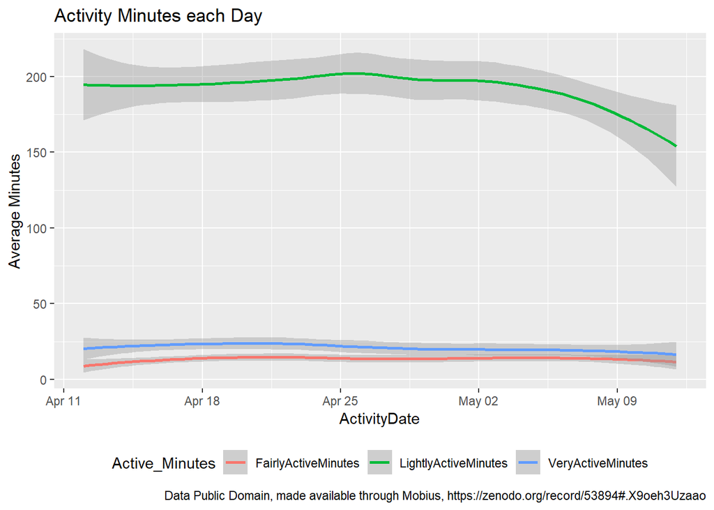

It becomes clear that the participants spent between 150 and 200 minutes each day on light activity (green), and less on fairly (red) and very active (blue) activities. As stated in the introductory part of this report light activity for example is walking with speed up to 2 mph.

Next I created few more columns to check out the share of each activity category of the total activity hours:

```
##        Id            totalActivehours share_very_active share_fairly_active
##  Min.   :1.504e+09   Min.   :0.000    Min.   :  0.000   Min.   : 0.000
##  1st Qu.:2.320e+09   1st Qu.:2.446    1st Qu.:  0.000   1st Qu.: 0.000
##  Median :4.445e+09   Median :4.117    Median :  3.030   Median : 3.313
##  Mean   :4.855e+09   Mean   :3.792    Mean   :  8.756   Mean   : 5.694
##  3rd Qu.:6.962e+09   3rd Qu.:5.287    3rd Qu.: 13.621   3rd Qu.: 8.425
##  Max.   :8.878e+09   Max.   :9.200    Max.   :100.000   Max.   :50.000
##                                       NA's   :83        NA's   :83
##  share_light_active
##  Min.   :  0.00
##  1st Qu.: 76.75
##  Median : 89.64
##  Mean   : 85.55
##  3rd Qu.:100.00
##  Max.   :100.00
##  NA's   :83
```

On average more than *85%* of the time people did light activity such as walking, followed by around *8.756%* of very active activity such as jogging.

This is also supported by the following barchart that shows that the most often logged intensity levels are below 1, which is light intensity. The chart shows the number of observations of each intensity level logged, excluding intensities of 0. (Source: https://www.fitabase.com/media/1930/fitabasedatadictionary102320.pdf).

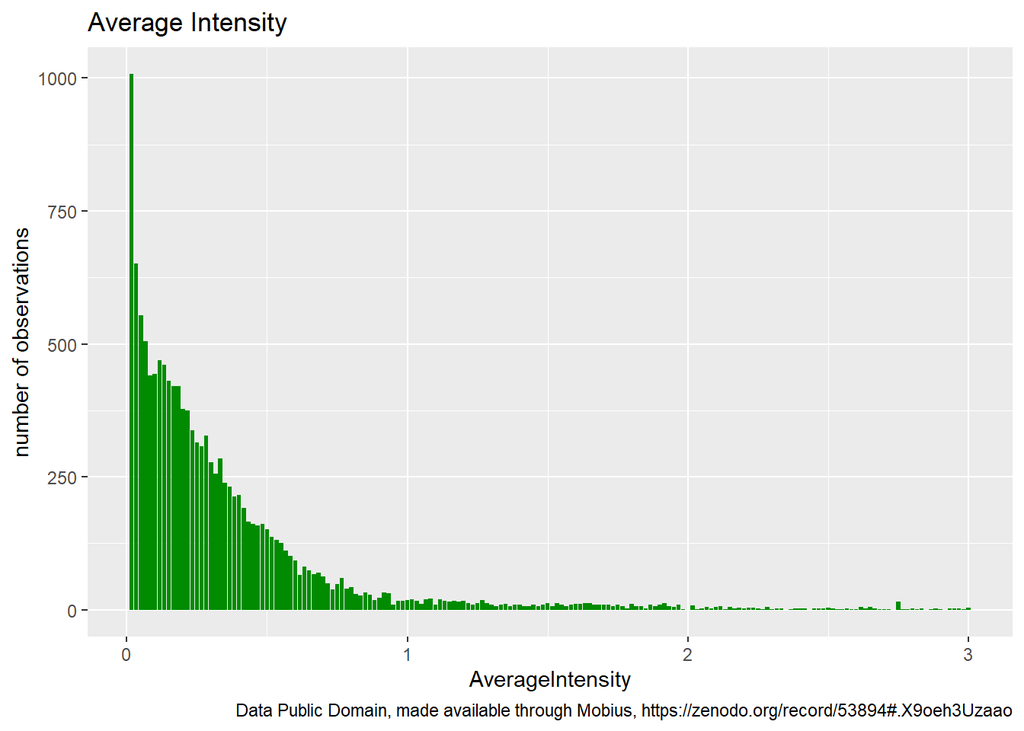

Here is the another visualization for each ID to get a sense of how many participants did what activity:

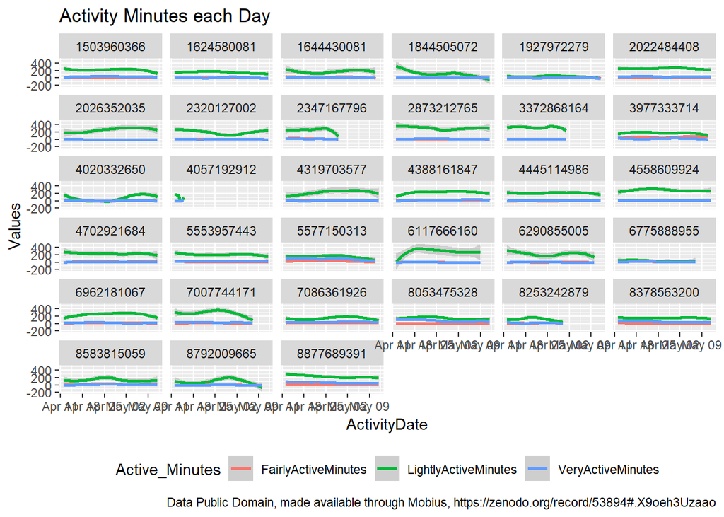

-> Only a minority has activities labeled “fairly active” (red lines) logged. However, most users do show very high intensity activities (blue lines)

###Next is a visualization of just fairly and very active activity:

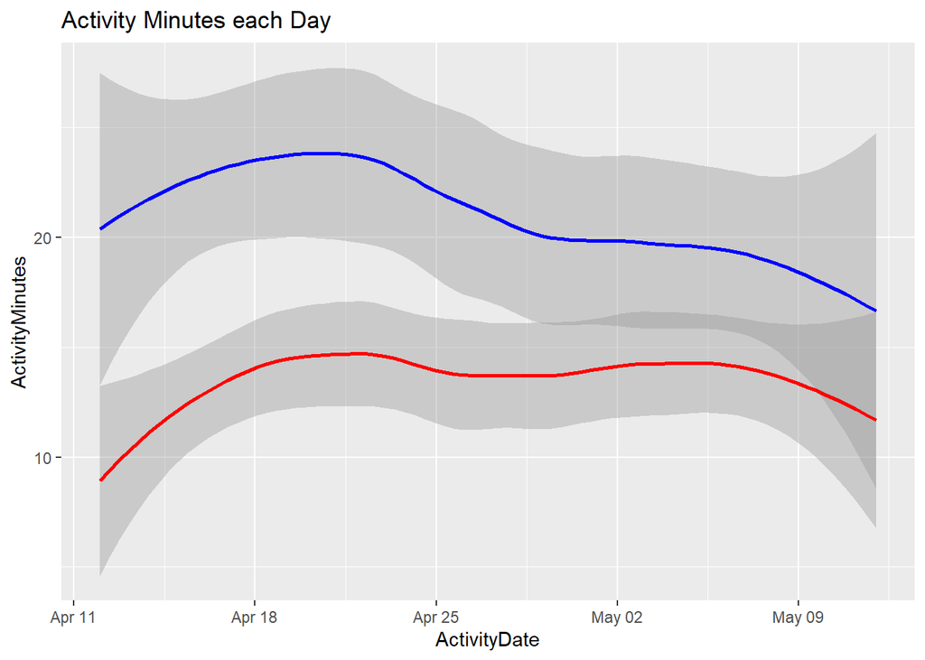

On average people did high intensity excercise of around 20 Minutes per day (blue), followed by around 10 minutes of fairly active exercise.

Next I calculate some further summary statistics for the data:

```
##   mean(TotalSteps) median(TotalSteps) min(TotalSteps) max(TotalSteps)
## 1         7637.911             7405.5               0           36019
##   mean(Calories) min(Calories) max(Calories) mean(SedentaryHours)
## 1        2303.61             0          4900             16.52018
##   median(SedentaryHours) max(SedentaryHours) min(SedentaryHours)
## 1                 17.625                  24                   0
##   cor(SedentaryHours, Calories) cor(SedentaryHours, TotalSteps)
## 1                     -0.106973                      -0.3274835
##   cor(SedentaryHours, VeryActiveMinutes) cor(TotalSteps, Calories)
## 1                              -0.164671                 0.5915681
##   mean(TrackerDistance) median(TrackerDistance) max(TrackerDistance)
## 1              5.475351                   5.245                28.03
##   cor(TrackerDistance, TotalSteps) cor(TrackerDistance, Calories)
## 1                        0.9848222                      0.6453133
```

Some observations over all Ids and days:

- Correlation between TotalSteps and Calories burned is moderately high (0.59)
- On average people had 16.52 sedentary hours per day, this is because on many days there is no or almost no activity recorded the whole day, see bar chart.
- As can be seen in the chart, there are 80 observations of 24 sedentary hours, this could mean that users on that day simply did not use their track
- Users also walked 7637.911 steps each day on average

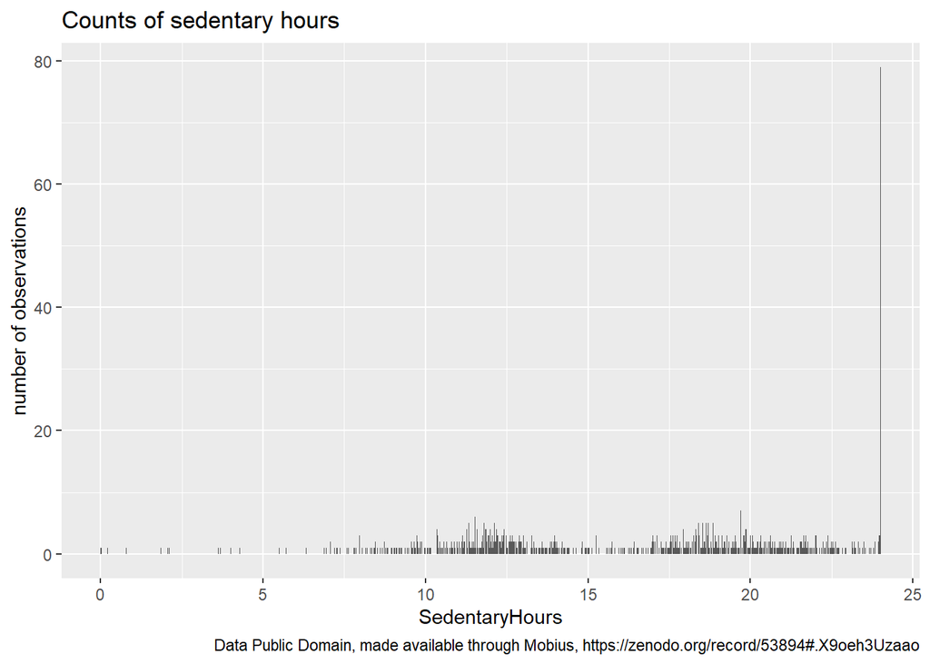

Next I plot calories burned and steps taken to visualize the relationship between how many steps people record with their devices and how many calories they burn.

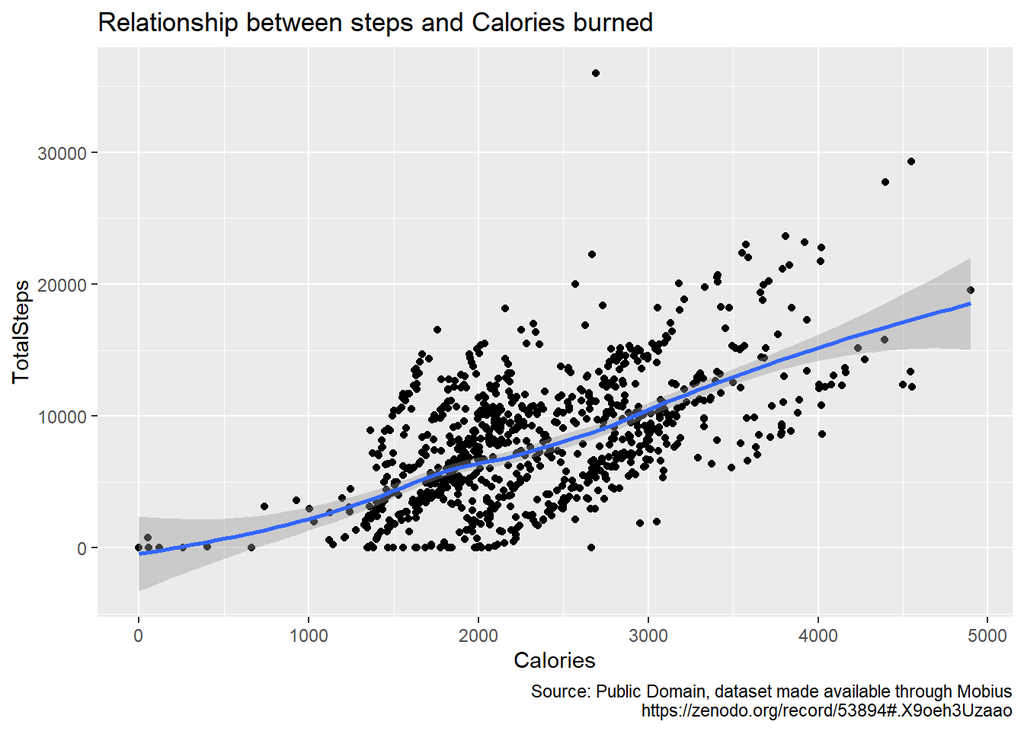

The relationship between total steps and burned calories is visible in the chart. However, there are a few data points where the user did not log any steps, but shows calories burned. This could indicate that users did some activities such as gymnastics or logged calories burned manually, however more investigation is needed to draw any conclusion.

In the next section I include data on weight and body mass index.

### Analysing data on weight and BMI

```r
# Transforming the date from string to date format


rawdate_BMI <- strptime(BMI_data$Date,format="%Y-%m-%d")

dates_BMI <- as.Date(rawdate_BMI,"%m%d%Y")


BMI_data <- BMI_data %>%

 mutate(Date = dates_BMI)
```

First I check again how many users are in the dataset:

```r
check_BMI <- BMI_data %>%
  tabyl(Id)

check_BMI
```

```
##          Id  n    percent valid_percent
##  1503960366  2 0.02941176    0.02985075
##  1927972279  1 0.01470588    0.01492537
##  2873212765  2 0.02941176    0.02985075
##  4319703577  2 0.02941176    0.02985075
##  4558609924  5 0.07352941    0.07462687
##  5577150313  1 0.01470588    0.01492537
##  6962181067 30 0.44117647    0.44776119
##  8877689391 24 0.35294118    0.35820896
##          NA  1 0.01470588            NA
```

- Only 8 users have BMI data in the tracker

Next merge the BMI and weight data with the main table.

```r
merged_data_BMI <- merge(x= main_data, y = BMI_data)

#head(merged_data)
str(merged_data_BMI)
```

```
## 'data.frame':    2076 obs. of  23 variables:
##  $ Id                      : num  1.5e+09 1.5e+09 1.5e+09 1.5e+09 1.5e+09 ...
##  $ ActivityDate            : Date, format: "2016-04-16" "2016-04-16" ...
##  $ TotalSteps              : int  12669 12669 13019 13019 9762 9762 10060 10060 9705 9705 ...
##  $ TotalDistance           : num  8.16 8.16 8.59 8.59 6.28 ...
##  $ TrackerDistance         : num  8.16 8.16 8.59 8.59 6.28 ...
##  $ LoggedActivitiesDistance: num  0 0 0 0 0 0 0 0 0 0 ...
##  $ VeryActiveDistance      : num  2.71 2.71 3.25 3.25 2.14 ...
##  $ ModeratelyActiveDistance: num  0.41 0.41 0.64 0.64 1.26 ...
##  $ LightActiveDistance     : num  5.04 5.04 4.71 4.71 2.83 ...
##  $ SedentaryActiveDistance : num  0 0 0 0 0 0 0 0 0 0 ...
##  $ VeryActiveMinutes       : int  36 36 42 42 29 29 44 44 38 38 ...
##  $ FairlyActiveMinutes     : int  10 10 16 16 34 34 8 8 20 20 ...
##  $ LightlyActiveMinutes    : int  221 221 233 233 209 209 203 203 164 164 ...
##  $ SedentaryMinutes        : int  773 773 1149 1149 726 726 574 574 539 539 ...
##  $ Calories                : int  1863 1863 1921 1921 1745 1745 1740 1740 1728 1728 ...
##  $ SedentaryHours          : num  12.9 12.9 19.1 19.1 12.1 ...
##  $ Date                    : Date, format: "2016-02-05" "2016-03-05" ...
##  $ WeightKg                : num  52.6 52.6 52.6 52.6 52.6 ...
##  $ WeightPounds            : num  116 116 116 116 116 ...
##  $ Fat                     : int  22 NA 22 NA 22 NA 22 NA 22 NA ...
##  $ BMI                     : num  22.6 22.6 22.6 22.6 22.6 ...
##  $ IsManualReport          : logi  TRUE TRUE TRUE TRUE TRUE TRUE ...
##  $ LogId                   : num  1.46e+12 1.46e+12 1.46e+12 1.46e+12 1.46e+12 ...
```

```r
#  drop_na()
```

Check out some summary statistics:

```r
sum_stats <- merged_data_BMI %>%
  summarise(mean_bmi = mean(BMI),max_bmi = max(BMI), min_bmi = min(BMI))


sum_stats
```

```
##   mean_bmi max_bmi min_bmi
## 1 25.18387   47.54   21.45
```

It appears that users of this fitness tracker in this dataset have an average BMI of 25.2 which is below the average BMI in the US (26.6 for men and 26.5 for women. (source:

https://www.cdc.gov/nchs/data/nhanes/databriefs/adultweight.pdf)

However, there is one outlier with a BMI of 47.54. Overall the users of the fitness tracker appear to have a lower BMI than, for example, the average person in the US.

# Sleep data

First I check how many people use the tracker to check their sleep.

```r
rawdate <- strptime(sleep_data$SleepDay,format="%Y-%m-%d")



dates <- as.Date(rawdate,"%m%d%Y")


sleep_data <- sleep_data %>%
  mutate(SleepDay = dates) %>%
  mutate(TotalHoursAsleep = TotalMinutesAsleep/60) %>%
  mutate(TotalHoursInBed = TotalTimeInBed /60) %>%
  mutate(HoursAwake = TotalHoursInBed-TotalHoursAsleep) %>%
  mutate(MinutesAwake = TotalTimeInBed-TotalMinutesAsleep)
```

```r
check <- sleep_data %>%
  tabyl(Id)

check
```

```
##          Id  n     percent
##  1503960366 25 0.060532688
##  1644430081  4 0.009685230
##  1844505072  3 0.007263923
##  1927972279  5 0.012106538
##  2026352035 28 0.067796610
##  2320127002  1 0.002421308
##  2347167796 15 0.036319613
##  3977333714 28 0.067796610
##  4020332650  8 0.019370460
##  4319703577 26 0.062953995
##  4388161847 24 0.058111380
##  4445114986 28 0.067796610
##  4558609924  5 0.012106538
##  4702921684 28 0.067796610
##  5553957443 31 0.075060533
##  5577150313 26 0.062953995
##  6117666160 18 0.043583535
##  6775888955  3 0.007263923
##  6962181067 31 0.075060533
##  7007744171  2 0.004842615
##  7086361926 24 0.058111380
##  8053475328  3 0.007263923
##  8378563200 32 0.077481840
##  8792009665 15 0.036319613
```

```r
summary(sleep_data)
```

```
##        Id               SleepDay   TotalSleepRecords TotalMinutesAsleep
##  Min.   :1.504e+09   Min.   :NA    Min.   :1.000     Min.   : 58.0
##  1st Qu.:3.977e+09   1st Qu.:NA    1st Qu.:1.000     1st Qu.:361.0
##  Median :4.703e+09   Median :NA    Median :1.000     Median :433.0
##  Mean   :5.001e+09   Mean   :NA    Mean   :1.119     Mean   :419.5
##  3rd Qu.:6.962e+09   3rd Qu.:NA    3rd Qu.:1.000     3rd Qu.:490.0
##  Max.   :8.792e+09   Max.   :NA    Max.   :3.000     Max.   :796.0
##                      NA's   :413
##  TotalTimeInBed  TotalHoursAsleep  TotalHoursInBed    HoursAwake
##  Min.   : 61.0   Min.   : 0.9667   Min.   : 1.017   Min.   :0.0000
##  1st Qu.:403.0   1st Qu.: 6.0167   1st Qu.: 6.717   1st Qu.:0.2833
##  Median :463.0   Median : 7.2167   Median : 7.717   Median :0.4167
##  Mean   :458.6   Mean   : 6.9911   Mean   : 7.644   Mean   :0.6529
##  3rd Qu.:526.0   3rd Qu.: 8.1667   3rd Qu.: 8.767   3rd Qu.:0.6667
##  Max.   :961.0   Max.   :13.2667   Max.   :16.017   Max.   :6.1833
##
##   MinutesAwake
##  Min.   :  0.00
##  1st Qu.: 17.00
##  Median : 25.00
##  Mean   : 39.17
##  3rd Qu.: 40.00
##  Max.   :371.00
##
```

On average people sleep *6.9911* hours per night, and people lay awake *40 Minutes* per night on average.

```r
merged_data <- merge(x= main_data,y = sleep_data, by = "Id", all.x = TRUE)

merged_data <- merged_data %>%
  drop_na()

head(merged_data)
```

```
##  [1] Id                       ActivityDate             TotalSteps
##  [4] TotalDistance            TrackerDistance          LoggedActivitiesDistance
##  [7] VeryActiveDistance       ModeratelyActiveDistance LightActiveDistance
## [10] SedentaryActiveDistance  VeryActiveMinutes        FairlyActiveMinutes
## [13] LightlyActiveMinutes     SedentaryMinutes         Calories
## [16] SedentaryHours           SleepDay                 TotalSleepRecords
## [19] TotalMinutesAsleep       TotalTimeInBed           TotalHoursAsleep
## [22] TotalHoursInBed          HoursAwake               MinutesAwake
## <0 rows> (or 0-length row.names)
```

```r
merged_data_analysis <- merged_data %>%
  summarise(cor(TotalSteps,MinutesAwake),cor(SedentaryMinutes,TotalMinutesAsleep),
            cor(VeryActiveMinutes,TotalDistance), cor(VeryActiveMinutes, MinutesAwake))

merged_data_analysis
```

```
##   cor(TotalSteps, MinutesAwake) cor(SedentaryMinutes, TotalMinutesAsleep)
## 1                            NA                                        NA
##   cor(VeryActiveMinutes, TotalDistance) cor(VeryActiveMinutes, MinutesAwake)
## 1                                    NA                                   NA
```